# **Data Science Final Portfolio**

By **Gabriel Epstein**

**Project Websites**

[Final Portfolio Website (Hosted by GitHub Pages)](https://gabrielepstein.github.io/Final-Portfolio/)

[Final Portfolio GitHub Page](https://github.com/GabrielEpstein/Final-Portfolio)

# **Project Background**

This project is my Final Portfolio Project for my Intro To Data Science Course (CMPS-3160) at Tulane University.

**Project Idea:** Accidental Drug Deaths During COVID-19 (In the next Milestone will include different locations and other demographics information)

**Relevant Links:**  
*The following data is used in Milestone 1*

[Connecticut Accidental Drug Death Data](https://catalog.data.gov/dataset/accidental-drug-related-deaths-2012-2018)

*The following data will be used in the project as well*

[National Center for Health Statistics Mortality Data (CDC Wonder)](https://wonder.cdc.gov/mcd.html)

[NCHS National Vital Statistics System Drug Overdose Death Data](https://www.cdc.gov/nchs/nvss/vsrr/drug-overdose-data.htm)

[IRS Tax Data](https://www.irs.gov/statistics)

# Project Goals

For this project, I, **Gabriel Epstein**, will be looking at drug overdose deaths in the United States. I am curious to see if covid 19 caused any interesting changes in drug overdose deaths, either by location (state), ethnicity, age, or any other factor. For this first milestone, I will be looking at data from my home state of Connecticut. This data is available in the above listed "Accidental Drug Death Dataset," and is derived from an investigation by the Office of the Chief Medical Examiner. It includes the toxicity report, the death certificate, and a bit of scene investigation results as well. which includes the toxicity report, death certificate, as well as a scene investigation.

In the upcoming future, I'd like to look at if changes in personal economic trends have any relevance to drug overdose deaths. I'd also like to see if there is a disproportionately affected group of people, whether by sexual orientation, race, age, etc.

Some of the relevant datasets are included above.

# Collaboration Plan

I will be doing this project on my own, so there is not much of a collaboration plan.

# **Let's Jump In!**

**Importing Libraries:** Below, I am importing some of the libraries I will be using to analyze this data. So far, I am using Pandas and NumPy libraries.

```python
#Importing pandas and numpy for use in analysis
import pandas as pd
import numpy as np

pd.set_option("display.max_rows", None, "display.max_columns", None)
```

**Importing Data:** Here, I am importing the dataset that I found from [Data.Gov](https://data.gov), the "home of the U.S. Government's Open Data." Then I will use the .head() function to visually verify that the dataset seems to have been imported without problems

```python
#Reading the csv and displaying the first n (5 by default) rows with .head()
whole_df = pd.read_csv('/content/drive/MyDrive/Colab Notebooks/Data Science Final Portfolio Files/Accidental_Drug_Related_Deaths_2012-2021.csv')
whole_df.head(10)
```

|  | Date | Date Type | Age | Sex | Race | Ethnicity | Residence City | Residence County | Residence State | Injury City | Injury County | Injury State | Injury Place | Description of Injury | Death City | Death County | Death State | Location | Location if Other | Cause of Death | Manner of Death | Other Significant Conditions | Heroin | Heroin DC | Cocaine | Fentanyl | Fentanyl Analogue | Oxycodone | Oxymorphone | … |
| --- | --- | --- | --- | --- | --- | --- | --- | --- | --- | --- | --- | --- | --- | --- | --- | --- | --- | --- | --- | --- | --- | --- | --- | --- | --- | --- | --- | --- | --- | --- |
| 0 | 05/29/2012 | Date of death | 37.0 | Male | Black | NaN | STAMFORD | FAIRFIELD | NaN | STAMFORD | NaN | CT | Residence | Used Cocaine | NaN | NaN | NaN | Residence | NaN | Cocaine Toxicity | Accident | NaN | NaN | NaN | Y | NaN | NaN | NaN | NaN | … |
| 1 | 06/27/2012 | Date of death | 37.0 | Male | White | NaN | NORWICH | NEW LONDON | NaN | NORWICH | NaN | CT | Residence | Drug Use | NORWICH | NEW LONDON | NaN | Hospital | NaN | Heroin Toxicity | Accident | NaN | Y | NaN | NaN | NaN | NaN | NaN | NaN | … |
| 2 | 03/24/2014 | Date of death | 28.0 | Male | White | NaN | HEBRON | NaN | NaN | HEBRON | NaN | CT | Residence | Drug Use | MARLBOROUGH | NaN | NaN | Hospital | NaN | Heroin Intoxication | Accident | NaN | Y | NaN | NaN | NaN | NaN | NaN | NaN | … |
| 3 | 12/31/2014 | Date of death | 26.0 | Female | White | NaN | BALTIC | NaN | NaN | NaN | NaN | NaN | NaN | NaN | BALTIC | NEW LONDON | NaN | Residence | NaN | Acute Heroin Intoxication | Accident | NaN | Y | NaN | NaN | NaN | NaN | NaN | NaN | … |
| 4 | 01/16/2016 | Date of death | 41.0 | Male | White | NaN | SHELTON | FAIRFIELD | CT | SHELTON | NaN | NaN | Residence | Drug Use | BRIDGEPORT | NaN | NaN | Hospital | NaN | Acute Fentanyl Intoxication | Accident | NaN | NaN | NaN | NaN | Y | NaN | NaN | NaN | … |
| 5 | 06/13/2017 | Date reported | 57.0 | Male | White | NaN | BLANDFORD | HAMPDEN | MA | ENFIELD | HARTFORD | CT | In Vehicle | Drug abuse | ENFIELD | HARTFORD | CT | Other | Roadway in vehicle | Acute Intoxication Cocaine Toxicity | Accident | NaN | NaN | NaN | Y | NaN | NaN | NaN | NaN | … |
| 6 | 10/20/2015 | Date reported | 26.0 | Male | White | NaN | DANBURY | FAIRFIELD | CT | DANBURY | NaN | NaN | Residence | NaN | DANBURY | FAIRFIELD | CT | Hospital | NaN | Acute Opioid Intoxication | Accident | NaN | NaN | NaN | NaN | NaN | NaN | NaN | NaN | … |
| 7 | 02/02/2017 | Date reported | 64.0 | Male | White | NaN | MILFORD | NEW HAVEN | CT | MILFORD | NEW HAVEN | CT | Residence | Ingestion | MILFORD | NEW HAVEN | CT | Residence | NaN | Acute Oxycodone Intoxication | Accident | NaN | NaN | NaN | NaN | NaN | NaN | Y | NaN | … |
| 8 | 07/03/2018 | Date of death | 33.0 | Male | NaN | NaN | NaN | NaN | NaN | HARTFORD | HARTFORD | NaN | Building | Drug Use | HARTFORD | HARTFORD | CT | Other | NaN | Acute Cocaine Intoxication | Accident | NaN | NaN | NaN | Y | NaN | NaN | NaN | NaN | … |
| 9 | 05/08/2013 | Date of death | 23.0 | Male | White | NaN | BETHEL | FAIRFIELD | NaN | BETHEL | NaN | CT | Residence | Inhalation | BETHEL | FAIRFIELD | NaN | Residence | NaN | Heroin Intoxication | Accident | NaN | Y | NaN | NaN | NaN | NaN | NaN | NaN | … |

Next, we will take a look at what types of objects are contained within the dataset

```python
#Getting the dtypes
whole_df.dtypes
```

```
Date                              object
Date Type                         object
Age                              float64
Sex                               object
Race                              object
Ethnicity                         object
Residence City                    object
Residence County                  object
Residence State                   object
Injury City                       object
Injury County                     object
Injury State                      object
Injury Place                      object
Description of Injury             object
Death City                        object
Death County                      object
Death State                       object
Location                          object
Location if Other                 object
Cause of Death                    object
Manner of Death                   object
Other Significant Conditions      object
Heroin                            object
Heroin DC                         object
Cocaine                           object
Fentanyl                          object
Fentanyl Analogue                 object
Oxycodone                         object
Oxymorphone                       object
Ethanol                           object
Hydrocodone                       object
Benzodiazepine                    object
Methadone                         object
Meth/Amphetamine                  object
Amphet                            object
Tramad                            object
Hydromorphone                     object
Morphine (Not Heroin)             object
Xylazine                          object
Gabapentin                        object
Opiate NOS                        object
Heroin/Morph/Codeine              object
Other Opioid                      object
Any Opioid                        object
Other                             object
ResidenceCityGeo                  object
InjuryCityGeo                     object
DeathCityGeo                      object
dtype: object
```

Next, we will do some clean up. I want to look at my data over time, so I will first convert the dates of type object into datetimes, sort said datetimes, and then set my index as the 'Date' to have my dataframe indexed by date and chronologically ordered.

```python
#DataFrame in its originally indexed state
whole_df.head(5)
```

|  | Date | Date Type | Age | Sex | Race | Ethnicity | Residence City | Residence County | Residence State | Injury City | Injury County | Injury State | Injury Place | Description of Injury | Death City | Death County | Death State | Location | Location if Other | Cause of Death | Manner of Death | Other Significant Conditions | Heroin | Heroin DC | Cocaine | Fentanyl | Fentanyl Analogue | Oxycodone | Oxymorphone | … |
| --- | --- | --- | --- | --- | --- | --- | --- | --- | --- | --- | --- | --- | --- | --- | --- | --- | --- | --- | --- | --- | --- | --- | --- | --- | --- | --- | --- | --- | --- | --- |
| 0 | 05/29/2012 | Date of death | 37.0 | Male | Black | NaN | STAMFORD | FAIRFIELD | NaN | STAMFORD | NaN | CT | Residence | Used Cocaine | NaN | NaN | NaN | Residence | NaN | Cocaine Toxicity | Accident | NaN | NaN | NaN | Y | NaN | NaN | NaN | NaN | … |
| 1 | 06/27/2012 | Date of death | 37.0 | Male | White | NaN | NORWICH | NEW LONDON | NaN | NORWICH | NaN | CT | Residence | Drug Use | NORWICH | NEW LONDON | NaN | Hospital | NaN | Heroin Toxicity | Accident | NaN | Y | NaN | NaN | NaN | NaN | NaN | NaN | … |
| 2 | 03/24/2014 | Date of death | 28.0 | Male | White | NaN | HEBRON | NaN | NaN | HEBRON | NaN | CT | Residence | Drug Use | MARLBOROUGH | NaN | NaN | Hospital | NaN | Heroin Intoxication | Accident | NaN | Y | NaN | NaN | NaN | NaN | NaN | NaN | … |
| 3 | 12/31/2014 | Date of death | 26.0 | Female | White | NaN | BALTIC | NaN | NaN | NaN | NaN | NaN | NaN | NaN | BALTIC | NEW LONDON | NaN | Residence | NaN | Acute Heroin Intoxication | Accident | NaN | Y | NaN | NaN | NaN | NaN | NaN | NaN | … |
| 4 | 01/16/2016 | Date of death | 41.0 | Male | White | NaN | SHELTON | FAIRFIELD | CT | SHELTON | NaN | NaN | Residence | Drug Use | BRIDGEPORT | NaN | NaN | Hospital | NaN | Acute Fentanyl Intoxication | Accident | NaN | NaN | NaN | NaN | Y | NaN | NaN | NaN | … |

Now, I will convert the 'Date' datatype into a datetime. Once I've done so, I will sort said datetime values, then index the dataframe by date.

```python
whole_df['Date'] = pd.to_datetime(whole_df['Date'])
#whole_df.info() used .info() in order to ensure that Date has been changed to dtype datetime instead of object

whole_df.sort_values(by='Date', inplace = True) #Sorting the 'Date' entries, and making sure the change is not in a temporary new dataframe with inplace = True
#whole_df.head(5)
df_by_date = whole_df.set_index('Date') #creating a new dataframe with the sorted 'Date' entries as the index
df_by_date.head(5)
```

| Date | Date Type | Age | Sex | Race | Ethnicity | Residence City | Residence County | Residence State | Injury City | Injury County | Injury State | Injury Place | Description of Injury | Death City | Death County | Death State | Location | Location if Other | Cause of Death | Manner of Death | Other Significant Conditions | Heroin | Heroin DC | Cocaine | Fentanyl | Fentanyl Analogue | Oxycodone | Oxymorphone | Ethanol | … |
| --- | --- | --- | --- | --- | --- | --- | --- | --- | --- | --- | --- | --- | --- | --- | --- | --- | --- | --- | --- | --- | --- | --- | --- | --- | --- | --- | --- | --- | --- | --- |
| 2012-01-01 | Date of death | 35.0 | Male | White | NaN | HEBRON | TOLLAND | NaN | HEBRON | NaN | CT | Residence | Drug Use | HEBRON | TOLLAND | NaN | Residence | NaN | Cocaine and Heroin Toxicity | Accident | NaN | Y | NaN | Y | NaN | NaN | NaN | NaN | NaN | … |
| 2012-01-03 | Date of death | 41.0 | Male | White | NaN | BRISTOL | HARTFORD | NaN | BRISTOL | NaN | CT | Residence | Ingestion | BRISTOL | HARTFORD | NaN | Hospital | NaN | Multiple Drug Toxicity | Accident | NaN | Y | NaN | NaN | NaN | NaN | NaN | NaN | NaN | … |
| 2012-01-04 | Date of death | 61.0 | Male | Black | NaN | DANBURY | FAIRFIELD | NaN | DANBURY | NaN | CT | Roadway | Used Cocaine | DANBURY | FAIRFIELD | NaN | Hospital | NaN | Cocaine Toxicity | Accident | NaN | NaN | NaN | Y | NaN | NaN | NaN | NaN | NaN | … |
| 2012-01-05 | Date of death | 51.0 | Male | White | NaN | STRATFORD | FAIRFIELD | NaN | STRATFORD | NaN | CT | Residence | Ingestion | BRIDGEPORT | FAIRFIELD | NaN | Other | Mother's Home | Methadone Toxicity | Accident | NaN | NaN | NaN | NaN | NaN | NaN | NaN | NaN | NaN | … |
| 2012-01-07 | Date of death | 45.0 | Male | White | NaN | HARTFORD | HARTFORD | NaN | HARTFORD | NaN | CT | Residence | Used Heroin | HARTFORD | HARTFORD | NaN | Residence | NaN | Heroin Toxicity | Accident | NaN | Y | NaN | NaN | NaN | NaN | NaN | NaN | NaN | … |

**Displaying Data:** As an introduction to graphing and displaying the data visually, I will show the histogram of deaths by age and the barplot of deaths by sex.

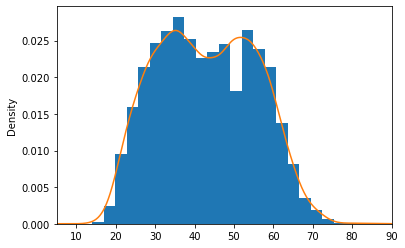

```python
#Getting some basic numerical information about the entries with 'Age' attributes
df_by_date['Age'].describe()

#Plotting the histogram, setting the number of bins, and enabling the density as the y axis
df_by_date.Age.plot.hist(bins = 25, density = True, xlabel = 'Age', sharex = True)
df_by_date.Age.plot.density(xlim = (5, 90), xlabel = 'Age', sharex = True)
```

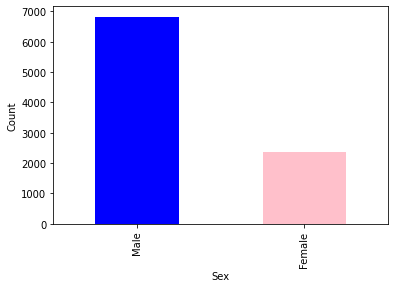

```python
#Since Sex is one of two values, I will get a count of each option ('Male', 'Female') to make a barlpot
sex_counts = df_by_date.Sex.value_counts()
sex_counts.plot.bar(ylabel = 'Count', xlabel = 'Sex', color = ['blue', 'pink'])
```